# Extension of the Simple SIR Model Simulation Report

Kimlee Chea @ https://kimleechea.github.io/

10/27/2021

```r
library(shiny)
library(sir)
```

## The Simple SIR Model

The SIR model is a model that identifies patterns in epidemics through the spread of disease in an exposed population. The SIR model is described using various mathematical functions. The attributes (or states) of the SIR model is as follows:

S - Susceptible  
I - Infectious  
R - Recovered

Susceptible indicates those persons/cells that haven’t been infected by the disease, and therefore, are vulnerable to the disease. Infectious indicates those that are actively infected and have the ability to infect others. Recovered indicates those that are removed from the actively infected status, and are henceforth, immune.

Above is a library call to a simple simulation of the SIR model.

In the following simulation, a matrix will be drawn to a plot over a series of time with values identifying the attributes of the SIR model.

## Plots Frame by Frame

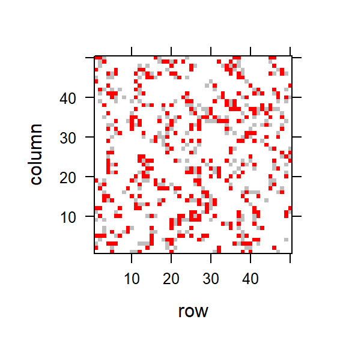

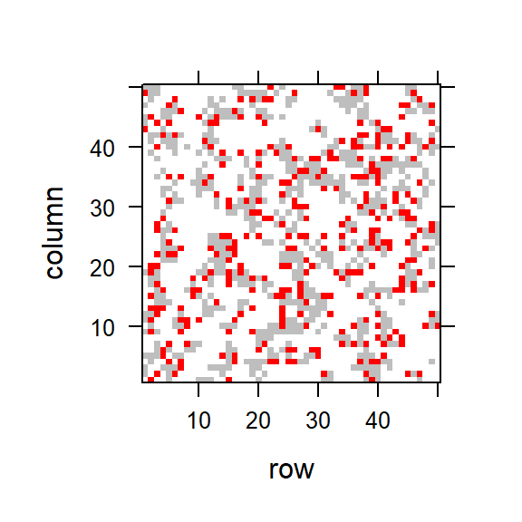

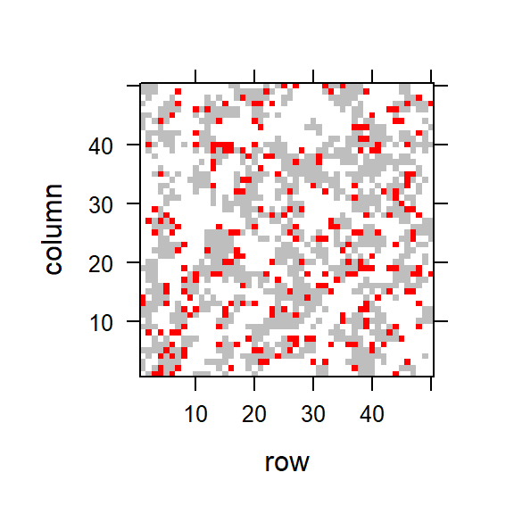

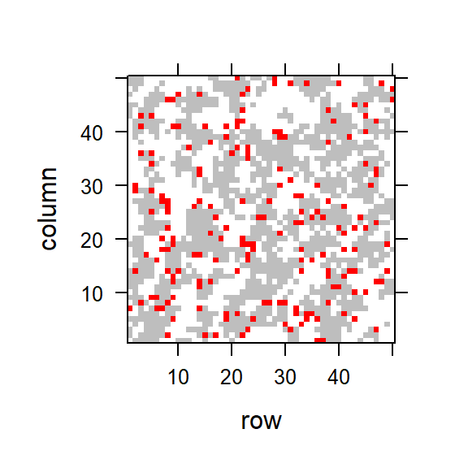

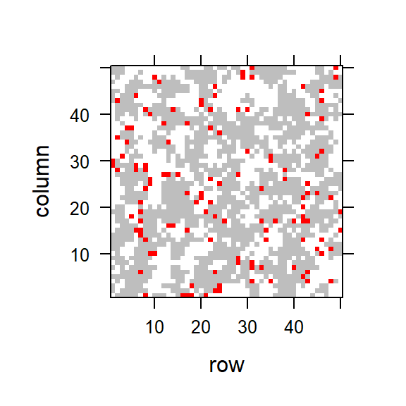

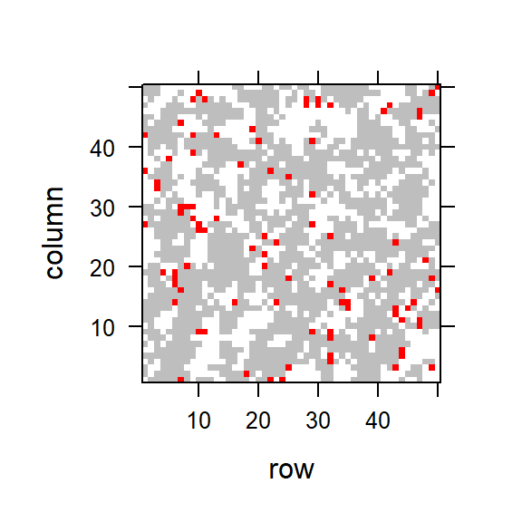

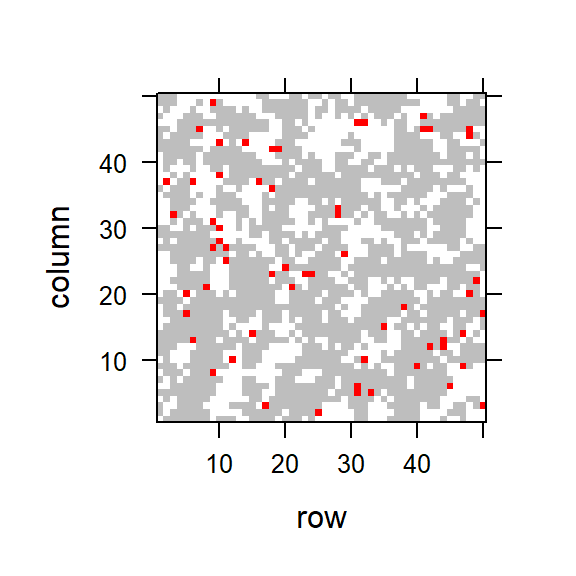

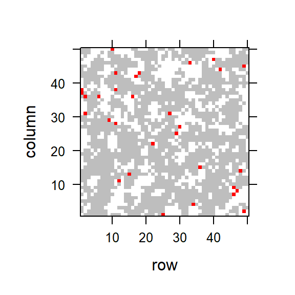

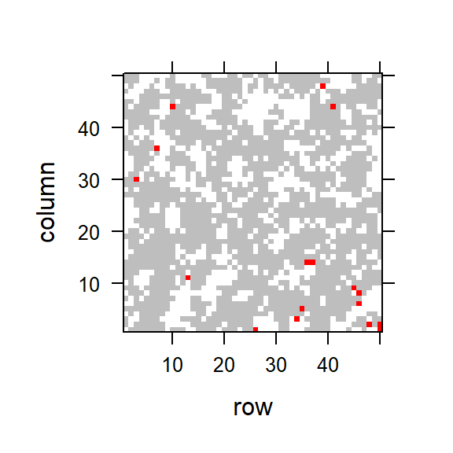

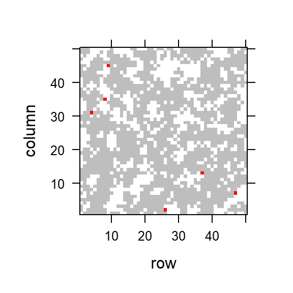

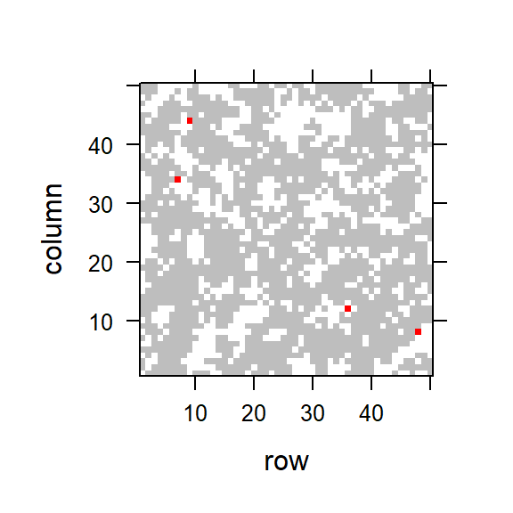

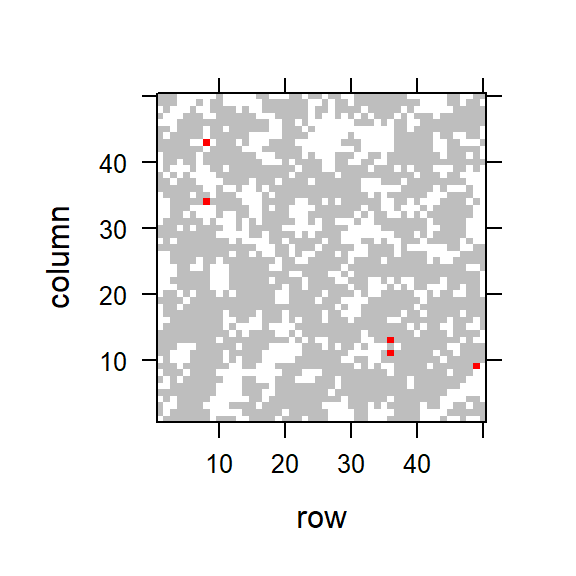

[5 more figures not shown]

```r
sir(plot = TRUE)
```

## Animated Plot Sample Run

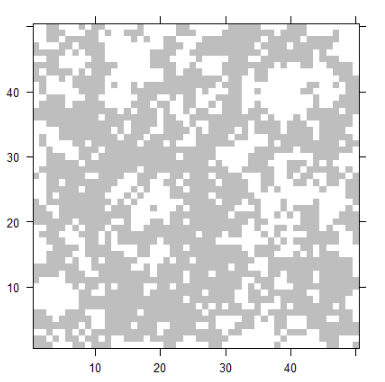

## Extension of the Simple SIR model

The extension of the SIR model that I chose to implement was the deployment of the simple SIR model simulation to a web application format. I believe the delivery of the model to a web application creates a unique experience for non-development associated individuals to explore the SIR model simulation through a robust and interactive approach. Demonstrations of the model simulation can be adapted to nearly any environment through this extension.

This extension was made possible with the assistance of the R Shiny web plugin tool.

Below is a snapshot demonstration of the extended SIR model simulation:

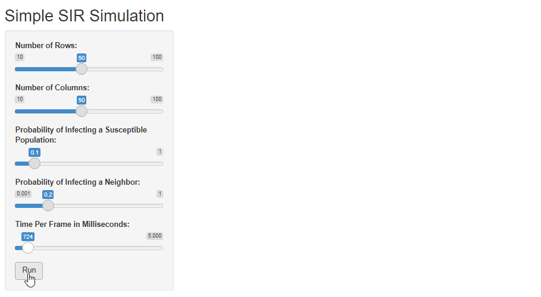

## Try it Yourself

[interactive chart not shown]

This embedded web application was made possible with https://www.shinyapps.io/. Learn how at https://shiny.rstudio.com/articles/shinyapps.html.

Through various trial and error, this extension was formed by drafting a remote package of library SIR on Github and adding it as a dependency when calling the deployment of the app for the first time. Note: do not install packages from within your shiny app! Rsconnect() will detect the package locally and install it to your shiny app server. External packages/libraries only need to be installed once!

## SIR Model Simulation Variability in Random Sampling

Variability in the SIR model simulation can be visualized by generating a plot that compiles a significant amount of simulation runs. In this case, we will illustrate a plot that describes the intensity of the random sampling distribution for at least 100 simulation runs.

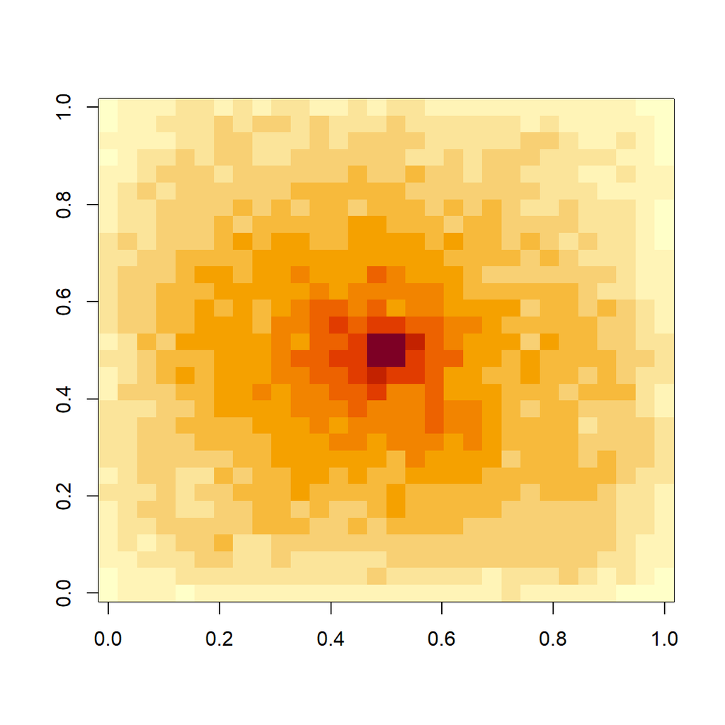

```r
library(sir)

# Set Seed
set.seed(1842)

# Initialize a matrix and infect two cells at the center
x = matrix(0L, nrow = 30, ncol = 30)
x[15:16, 15:16] = 1L
step_susceptible(step_infection())

# Let number of iterations = 100
i = 100

# Replicate SIR simulations to generate a compilation of
# generated plots mapped by color encoded intensity (heatmap)
result = replicate(i, sir(x, plot = FALSE, p = 0.25), simplify = FALSE)
iterateAll = lapply(result, `[[`, "x")
iterateSum = Reduce(`+`,iterateAll, init = 0)
image(t(iterateSum))
```